# İkinci el otomobil fiyatlarını belirleyen etkenler

**Erol Taymaz**  
İktisat Bölümü  
Orta Doğu Teknik Üniversitesi

20 Mart 2017

# Konular

- Niçin R?
- Türkiye’de ikinci el otomobil fiyatlarını belirleyen etkenler nelerdir?

# R nedir?

- Bir programlama dili
- İstatistik programı
- İstatistiksel hesaplama ve görselleştirme ortamı
- Bir “topluluk”" tarafından geliştirilen bir sistem
  - Veri, program ve yardımcı belgeler içeren “paketler” ile genişletilebilir

# Niçin R?

Veya niçin Stata, veya SPSS … değil?

- Esnek bir programlama dili
- Platform bağımsız (Linux, Mac, Windows, PC, server)
- Açık kaynak (open source)
  - Kaynak kodu açık
- Özgür yazılım (free software)
  - Kaynak kodu incelemekte özgürlük
  - Kaynak kodu değiştirmekte özgürlük
  - Değiştirilen kodu dağıtmakta özgürlük
- Ücretsiz yazılım (free of charge)

# Niçin R?

- Herkes, her yerde kullanabilir
  - Öğrenciler kendi bilgisayarlarına yükleyebilir
- Programı ve sonuçlarını başkaları ile paylaşmak kolay
- Tüm bilimsel alanlar için uygun (sadece iktisat değil)
  - Yaygın, çeşitli ve büyüyen bir topluluk
  - Hızla artan “paket”" sayısı
- Diğer (açık kaynak) programlarla kolay etkileşim (web, sunum, veri tabanı, büyük veri, vb)
- Açık kaynak araştırma uygulama araçlarının bir parçası
  - Veri analizinden raporlamaya kadar, web için, tez için…

# Niçin açık kaynak/özgür yazılım?

- Dinamik/akademik kullanıcı ve programcılar
- Bilimsel araştırma dili ve yöntemi

# İkinci el otomobil fiyatlarını belirleyen etkenler

- Faydası
  - Ulaşım hizmetleri [sabit]
    - Konfor, güvenlik vb
- Maliyeti
  - Yakıt [sabit]
  - Bakım onarım [artan]
  - Vergi [azalan]

# İkinci el otomobil fiyatlarını belirleyen etkenler

- Faydası
  - Ulaşım hizmetleri [sabit]
    - Konfor, güvenlik vb
  - Prestij [U-form]
- Maliyeti
  - Yakıt [sabit]
  - Bakım onarım [artan]
  - Vergi [azalan]
  - Yolda kalma riski [artan]

$$p_t = \int_t^T (f_t - m_t) dt$$

# Veri kaynağı

- [sahibinde.com](http://www.sahibinden.com)
- 5-6 Ağusto 2016
- Arama komutu https://www.sahibinden.com/renault/dizel/manuel?a5_max=2015&a5_min=2015&a706=32474&&pagingSize=50

# Değişkenler

- Marka (Renault, Volkswagen, Opel, Ford, Fiat, BMW, Tofas, Hyundai, Mercedes-benz, Toyota, Peugeot, Honda, Audi, Citroen, Skoda, Seat, Chevrolet, Volvo, Kia, Nissan, Dacia, Mazda, Lada)
  - Kullanılmayan markalar: Lada Chevrolet, Tofas
- Seri (for Renault, Clio, Fluence, Megane, Twingo, …)
- Model (for Megane, 1.4 Extreme, 1.4 T Color Edition, …)
- Yakıt (dizel, benzin, benzin-lpg)
- Vites (otomatik, yari-otomatik, manuel)
- Satıcı (sahibi, galeri/yetkili bayi)
- Yıl (yaş, 2016 = 0)
- km
- Renk (Beyaz-Gri-Gümüş Grisi, diğer)
- Motor büyüklüğü
- İl/ilçe (İstanbul, Ankara, diğer)
- Reklam metni (harf)
- Fiyat

# Genel istatistikler

| Statistic | N | Mean | St. Dev. | Min | Max |
| --- | --- | --- | --- | --- | --- |
| yil | 242,395 | 2,006.973 | 6.885 | 1,967 | 2,016 |
| km | 242,395 | 129,381.900 | 82,300.270 | 1 | 499,999 |
| fiyat | 242,395 | 47,122.770 | 39,954.620 | 750 | 499,000 |
| istanbul | 242,395 | 0.263 | 0.440 | 0 | 1 |
| ankara | 242,395 | 0.115 | 0.320 | 0 | 1 |
| engine.size | 238,567 | 1,831.477 | 23,243.810 | 10 | 600,600 |
| reklam | 242,395 | 39.838 | 15.957 | 9 | 67 |
| white | 242,395 | 0.582 | 0.493 | 0 | 1 |
| automatic | 242,395 | 0.114 | 0.318 | 0 | 1 |
| semiautomatic | 242,395 | 0.222 | 0.416 | 0 | 1 |
| owner | 242,395 | 0.618 | 0.486 | 0 | 1 |
| diesel | 242,395 | 0.419 | 0.493 | 0 | 1 |
| lpg | 242,395 | 0.341 | 0.474 | 0 | 1 |

# Tüm gözlemler

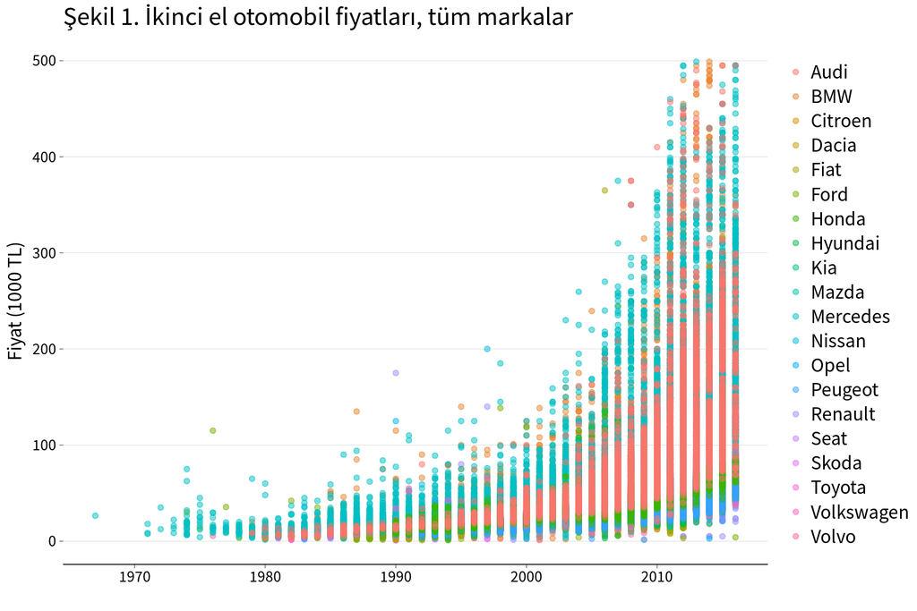

# Tüm gözlemler

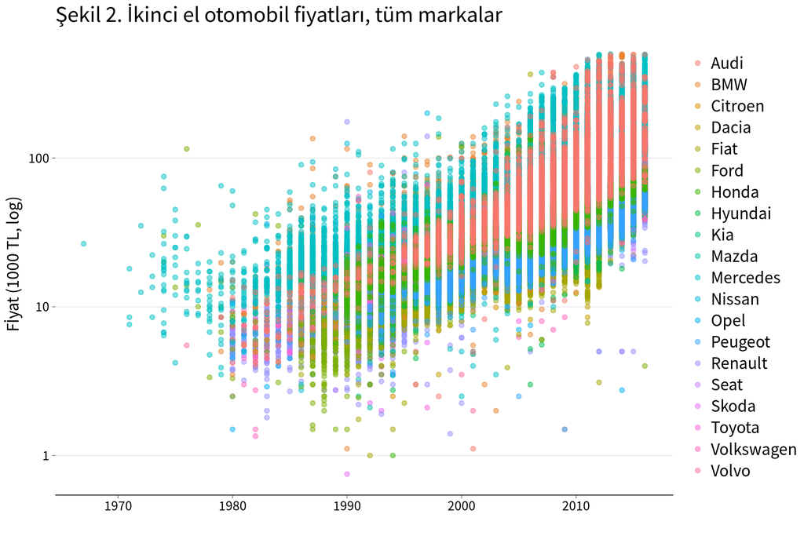

# Yıl etkileri

- Model
  - lm(log(fiyat) ~ seri + log(km) + white + seller + shift + fuel + istanbul + ankara + reklam + dyear, data=sub.data)
- Yıl kukla değişkenleri
- Tüm markalar için ayrı ayrı tahmin edildi
- Yıl değişkenlerinin katsayıları

# Yıl etkileri

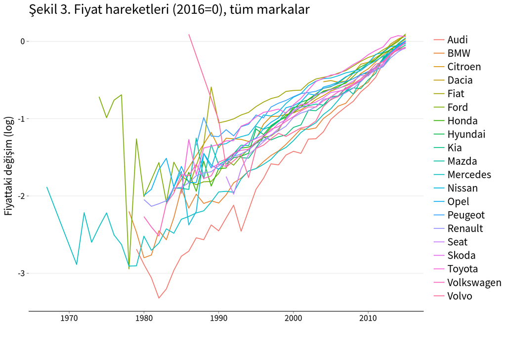

# Yıl etkileri - 2010 sonrası

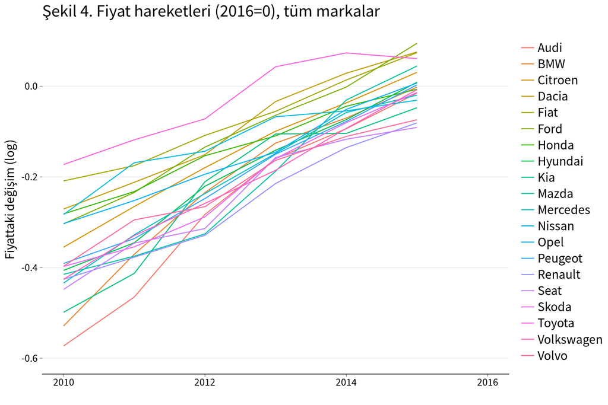

# Yıl etkileri - Toyota

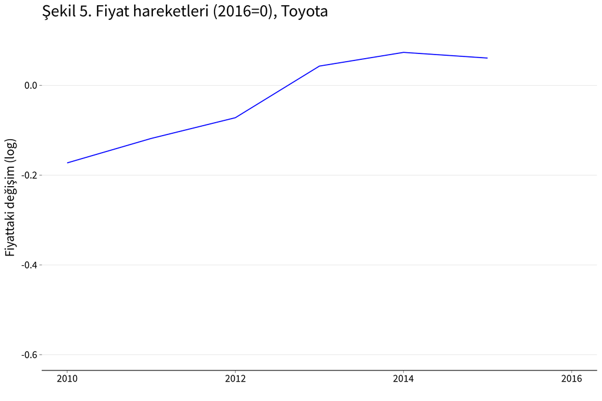

# Tahmin sonuçları

- Model:
  - log(fiyat) ~ seri + log(km) + owner + seller + shift + fuel + istanbul + ankara + reklam + yil + owner:yil + shift:yil + fuel:yil
- **yil** otomobilin yaşı (2016 - model yılı)
- Model her marka için ayrı ayrı tahmin edildi
- 29 yaşından büyük otomobiller tahminde kullanılmadı

# İkinci el otomobil fiyatlarındaki değişim, tüm markalar

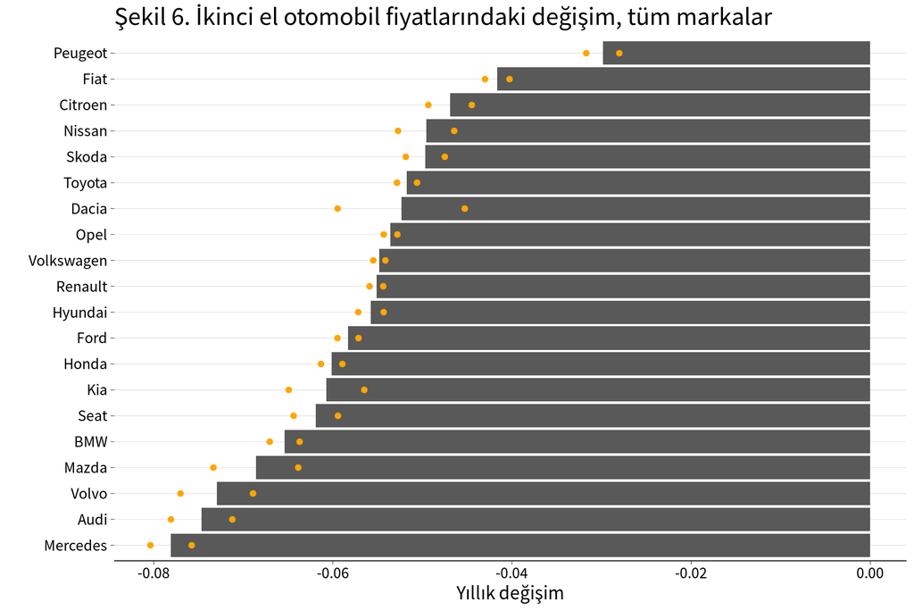

# km etkisi

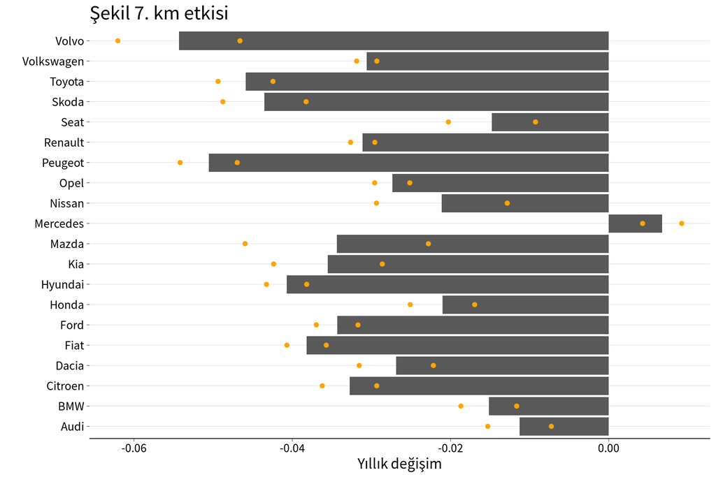

# Renk etkisi - fiyat farklılığı

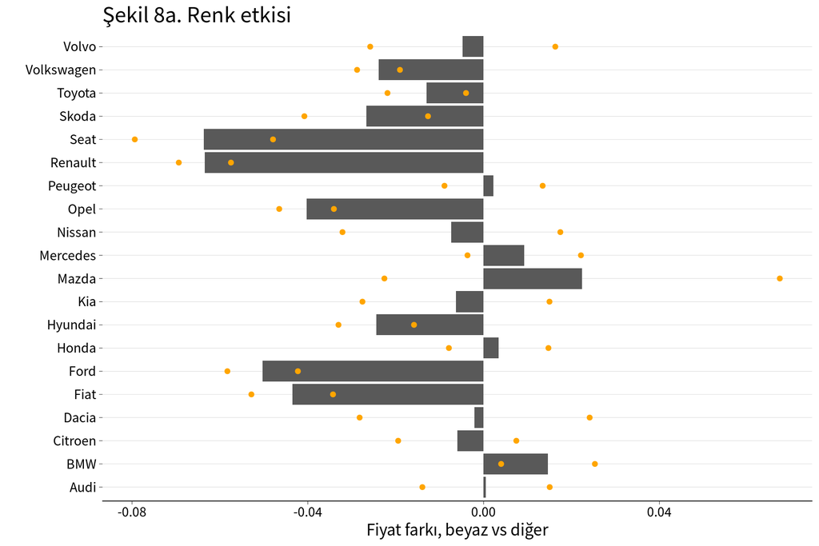

# Renk etkisi - zaman boyutu

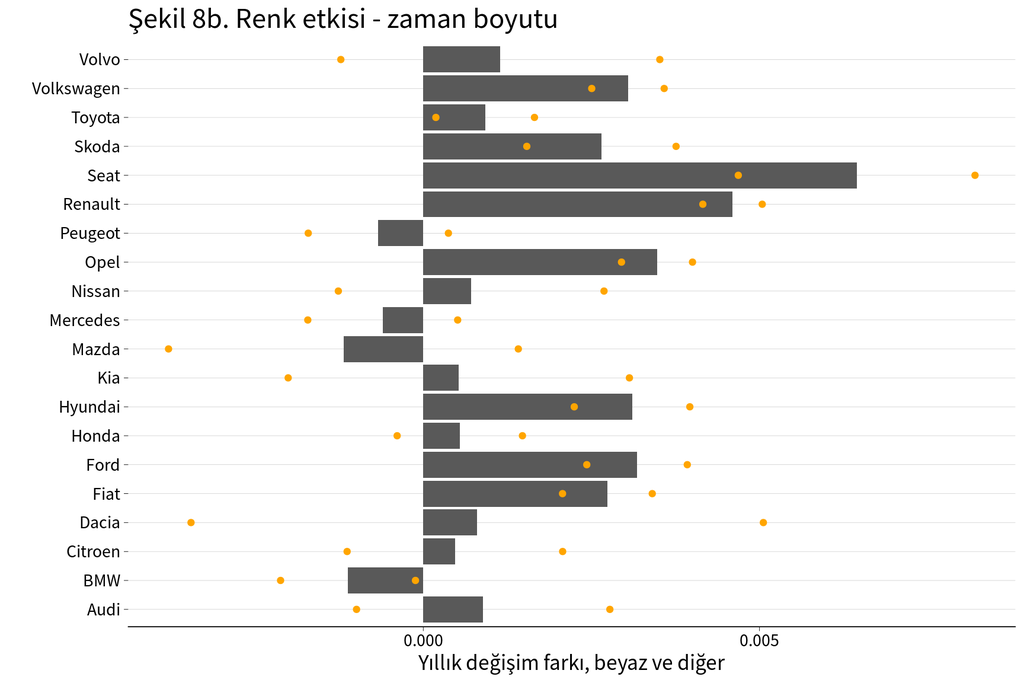

# Yakıt tipi etkisi - fiyat farklılığı

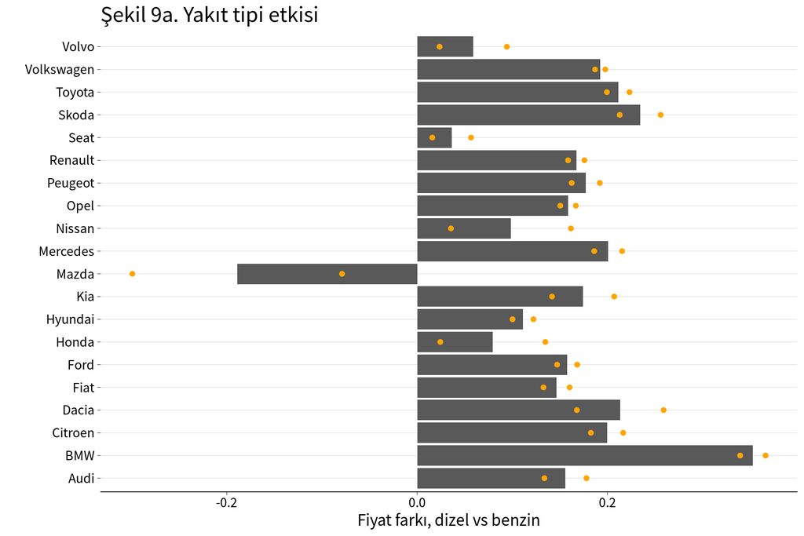

# Yakıt tipi etkisi - zaman boyutu

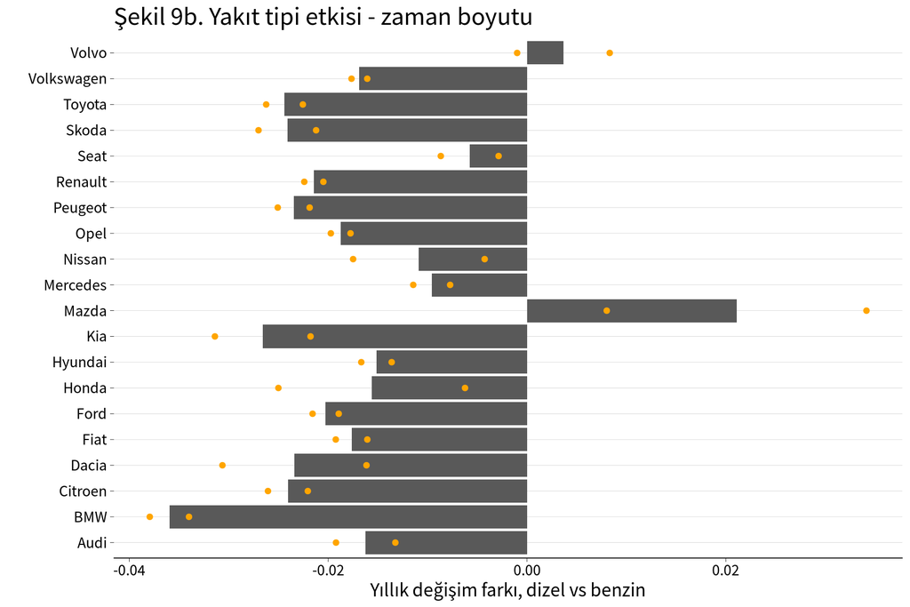

# Yakıt tipi etkisi - fiyat farklılığı

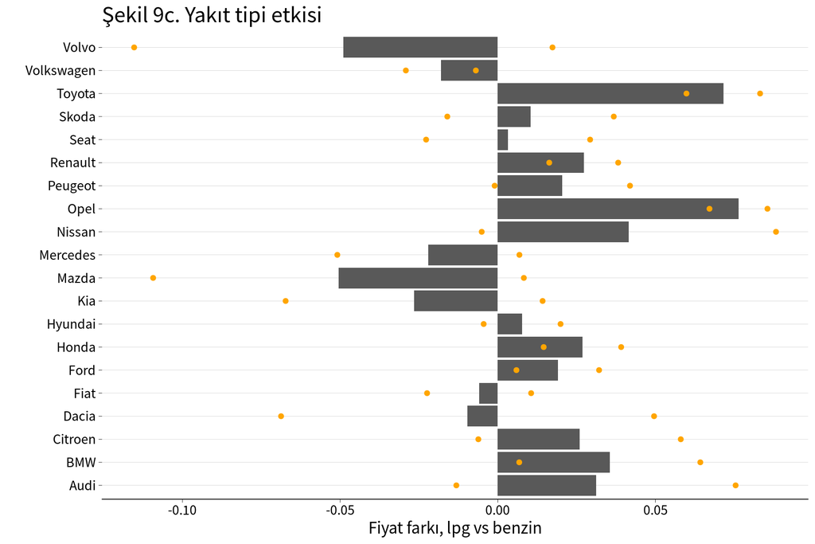

# Yakıt tipi etkisi - zaman boyutu

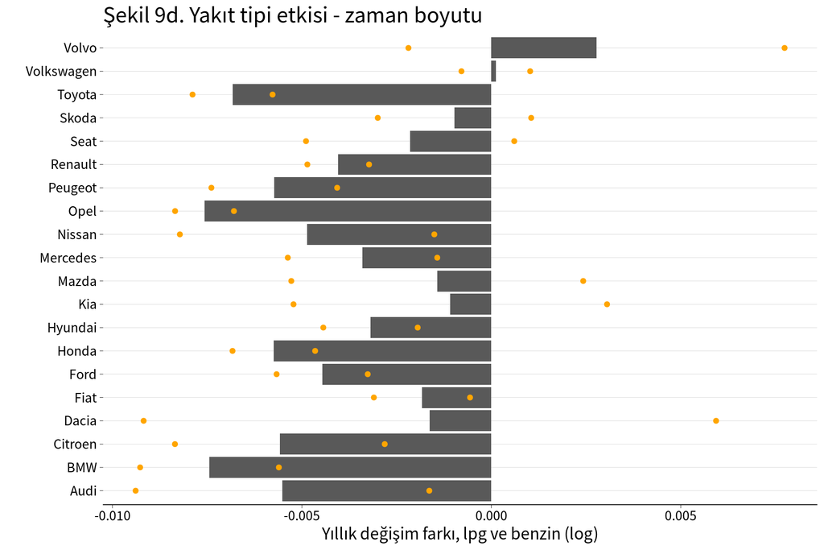

# Vites etkisi

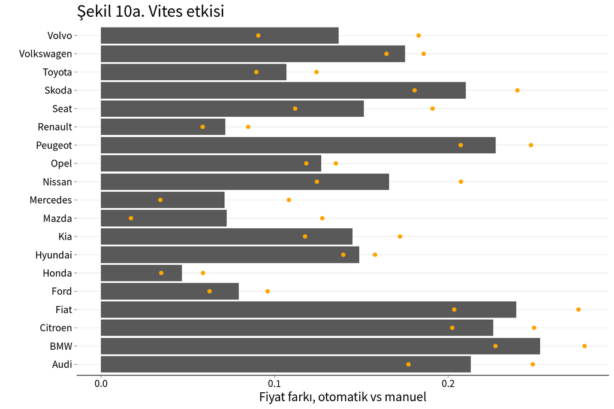

# Vites etkisi - zaman boyutu

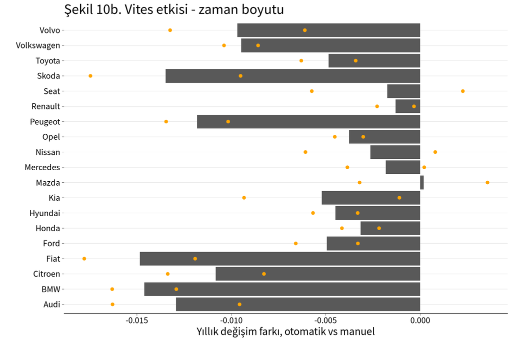

# Satıcı etkisi

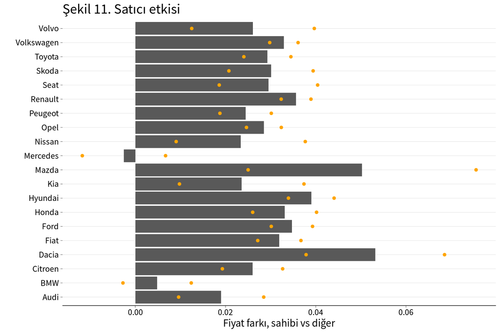

# İstanbul etkisi

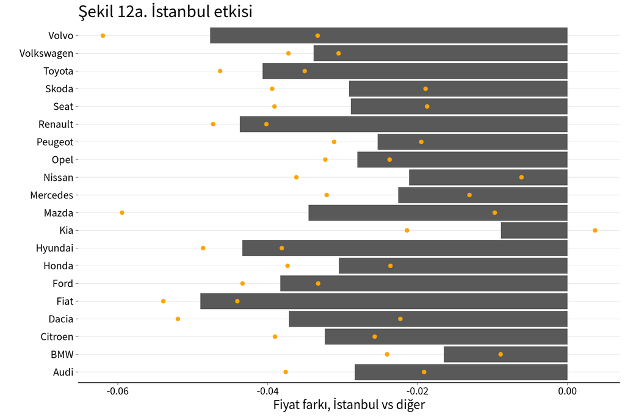

# Ankara Etkisi

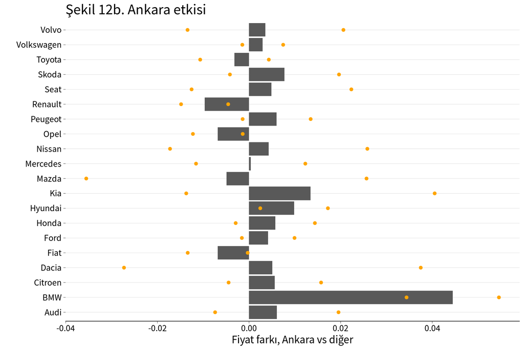

# Reklam büyüklüğü etkisi

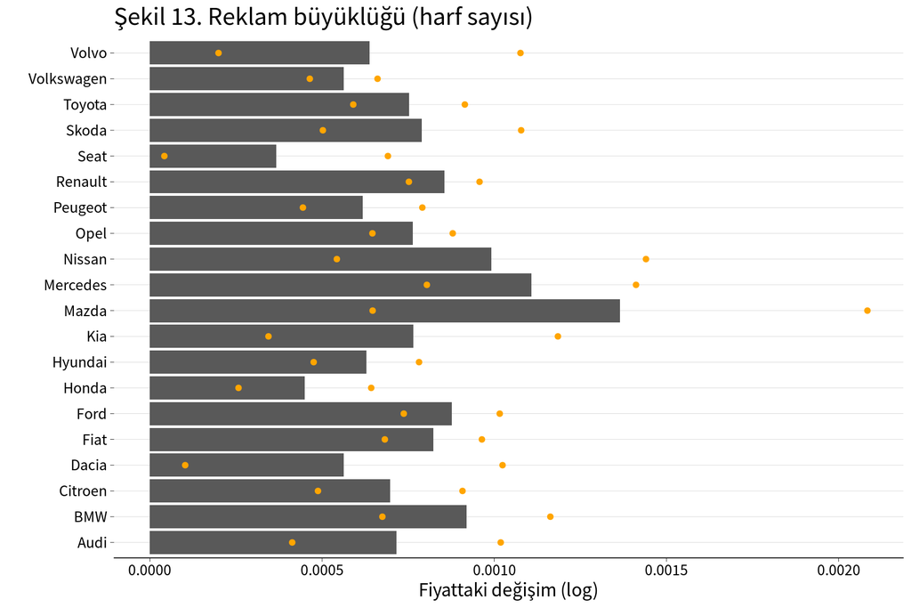

# Sonuçlar

- Hangi model?